# Problem 2

```r
data("gotv")
coln <- colnames(gotv)
set.seed(14142)
ind <- sample(nrow(gotv), nrow(gotv)/5)
train <- gotv[-ind,]
test <- gotv[ind,]
```

We write a simple function to determine the classification error

```r
check_err <- function(arr1, arr2){
  count = 0
  for (i in 1:length(arr1)){
    if (arr1[i] == arr2[i]) {
      count = count + 1
    }
  }
  return (1 - (count/length(arr1)))
}
```

## Part (a)

#### Design of tree from scratch

I adopt a simplistic approach to creating the tree by determining best split based on highest information gain. Then, using recursion, I will keep creating child nodes. I calculate the information gain based on difference of gini impurity for the parent vis-a-vis the children nodes.

For the tree, I will go to the left node whenever the answer is Yes. For categorical variables, the question is Var = 1?, and for age variable, the question is Var < age_value?

```r
#Function to calculate Gini Impurity
gini_impurity <- function(df) {
  y_arr <- df$voted
  n_arr <- length(y_arr)
  p1 <- sum(y_arr == 1)/n_arr
  p0 <- sum(y_arr == 0)/n_arr
  gini_impurity <- 1 - p1**2 - p0**2
  return(gini_impurity)
}

#Function to calculate Information Gain
info_gain <- function(left, right, parent){
  l_weight <- nrow(left)/nrow(parent)
  r_weight <- nrow(right)/nrow(parent)
  info_gain <- gini_impurity(parent) - l_weight*gini_impurity(left) - r_weight*gini_impurity(right)
  return(info_gain)
}

#Function to create a split.
#Since Age is a continuous variable and all others are categorical, I treat them differently.
create_split <- function(df, col_name, col_value) {
  if (col_name != 'age'){
    left_rows <- which(df[[col_name]] ==  col_value)
    left <- df[left_rows,]
    right <- df[-left_rows,]
  }
  else{
    left_rows <- which(df[[col_name]] <  col_value)
    left <- df[left_rows,]
    right <- df[-left_rows,]
  }
  return(list(left,right))
}

#Finding split which maximized information gain
find_best_split <- function(df){
  best_gain <- 0
  split_col_name <- NULL
  split_col_value <- NULL
  age_ls <- unique(df$age) #to check on all age values within the sub-dataset
  for (i in 1:8){
    if (coln[i] != 'age'){
      splits <- create_split(df,coln[i],1)
      if (nrow(splits[[1]]) == 0 |nrow(splits[[2]]) == 0){
        next
      }
      else{
        gain <- info_gain(splits[[1]],splits[[2]],df)
        #Update gain and split points only if I can improve gain
        if (gain > best_gain){
          best_gain <- gain
          split_col_value <- 1
          split_col_name <- coln[i]
          min_obs <- min(nrow(splits[[1]]),nrow(splits[[2]]))
        }
      }
    }
    else{
      for (j in 1:length(age_ls)){
        splits <- create_split(df,coln[i],age_ls[j])
        if (nrow(splits[[1]]) == 0 |nrow(splits[[2]]) == 0){
          next
        }
        else{
          gain <- info_gain(splits[[1]],splits[[2]],df)
          if (gain > best_gain){
              best_gain <- gain
              split_col_value <- age_ls[j]
              split_col_name <- coln[i]
              min_obs <- min(nrow(splits[[1]]),nrow(splits[[2]]))
          }
        }
      }
    }
  }
  return(c(best_gain,split_col_name,split_col_value))
}

det_criteria <- function(x,y){
  if (y != 'age'){
    if (x%%2 == 1){
      return('Yes')
    }
    else{
      return('No')
    }
  }
  else{
    if (x%%2 == 1){
      return('Less than')
    }
    else{
      return('More or equal')
    }
  }
}
```

Creating the tree (finally!)

```r
#Initiating a global dataframe to store the results of the tree
output_tree <- data.frame(node_number = integer(), #store the current node
                          split_var = character(), #store the variable on which the tree needs to be split
                          split_value = integer(), #store the value condition at which the tree needs to be split
                          parent = integer(), #store the parent node
                          leaf_log = logical(), #store TRUE if its the terminal node
                          y_val = integer(), # predicted output based on construction tree
                          criteria = character()) # move to current node if criteria is met - only for reading the table
output_tree[1,] <- c(0,NA,NA, -1, FALSE, NA, 'Root')

build_tree <- function(df,curr_node, parent_node, variable, value){
  est_val <- NA
  leaf = FALSE

  #Pushing node details into the dataframe
  if (!curr_node %in% output_tree$node_number) {
    if (curr_node != 0){
    newval <- data.frame(node_number = curr_node, split_var = variable , split_value = value , parent = parent_node, leaf_log = leaf, y_val = est_val, criteria = det_criteria(curr_node, variable))
    output_tree <<- rbind(output_tree, newval)
    }
  }

  #Creating a split on the current node
  split_val <- find_best_split(df)

  #Stopping criterion for determining terminal node
  if (split_val[1] == 0 | curr_node >= 2**(max_depth-1) | nrow(df) < min_node_size) {
    est_val <- round(sum(df$voted)/nrow(df)) #majority vote for estimating predicted value at terminal node
    output_tree[output_tree$node_number == curr_node,]$leaf_log <<- TRUE
    output_tree[output_tree$node_number == curr_node,]$y_val <<- est_val
  }
  #Recursive call to create children nodes if stopping criterion not met
  else{
    branches <- create_split(df,split_val[2],split_val[3])
    left_branch <- build_tree(branches[[1]],1 + curr_node*2, curr_node, split_val[2], split_val[3])
    right_branch <- build_tree(branches[[2]], 2 + curr_node*2 , curr_node, split_val[2], split_val[3])
  }
}
```

#### Fiting on the training dataset

```r
max_depth <- 6  #Maximum depth of the tree
min_node_size <- 1 #Minimum number of observations in a node
build_tree(train,0,0,NA,NA)
print(output_tree)
```

```
##    node_number split_var split_value parent leaf_log y_val      criteria
## 1            0      <NA>        <NA>     -1    FALSE  <NA>          Root
## 2            1     p2002           1      0    FALSE  <NA>           Yes
## 3            3     p2004           1      1    FALSE  <NA>           Yes
## 4            7     p2000           1      3    FALSE  <NA>           Yes
## 5           15       age          47      7    FALSE  <NA>     Less than
## 6           31     g2002           1     15    FALSE  <NA>           Yes
## 7           63       age          41     31     TRUE     1     Less than
## 8           64       age          41     31     TRUE     1 More or equal
## 9           32     g2002           1     15     TRUE     0            No
## 10          16       age          47      7    FALSE  <NA> More or equal
## 11          33     g2002           1     16     TRUE     1           Yes
## 12          34     g2002           1     16     TRUE     0            No
## 13           8     p2000           1      3    FALSE  <NA>            No
## 14          17       age          50      8    FALSE  <NA>     Less than
```

[output cut: 51 more lines]

#### Traversing a tree to predict outcome

```r
tree_traverse <- function(df, tree = output_tree, curr_node = 0) {
  terminal <- FALSE
  #Running the loop until I reach terminal node
  while (terminal == FALSE) {
    var <- unique(tree[tree$parent == curr_node,]$split_var)
    check_val <- unique(tree[tree$parent == curr_node,]$split_val)
    if (var != 'age') {
      if (df[var] == check_val){
        curr_node <- 1 + curr_node*2    #If True or Yes, move to the left side child node
      }
      else{
        curr_node <- 2 + curr_node*2    #If False or No, move to the right side child node
      }
    }
    else{
      if (df[var] < check_val){
        curr_node <- 1 + curr_node*2    #If less than, move to the left side child node
      }
      else{
        curr_node <- 2 + curr_node*2    #If more than, move to the right side child node
      }
    }
    terminal <- tree[tree$node_number == curr_node,]$leaf_log
  }
  est_y <- tree[tree$node_number == curr_node,]$y_val #If terminal node reached, determine the predicted outcome for the observation
  return(est_y)
}

#Function to create the prediction array based on input dataset
predict_tree_output <- function(df) {
  pred_y <- apply(df,1,tree_traverse)
  return(pred_y)
}
```

#### Training accuracy

```r
#Classification Accuracy on Training Set
train$pred <- predict_tree_output(train)
scratch_train_error <- check_err(train$voted, train$pred)
print(1 - scratch_train_error)
```

```
## [1] 0.7136663
```

The classification accuracy on the training set is 0.7136663, and the classification error is 0.2863337

## Part (b)

```r
#Classification error on Test Set
test$pred <- predict_tree_output(test)
scratch_test_error <- check_err(test$voted, test$pred)
print(scratch_test_error)
```

```
## [1] 0.2899198
```

## Part (c)

#### Creating the model with Rtree

```r
#Refreshing the dataset since the previous ones were added with prediction columns
train <- gotv[-ind,]
test <- gotv[ind,]

model_tree <- rpart(voted ~ ., data = train, method = "class", control = list(maxdepth = 6), cp = -1)
test$rtree_pred <- predict(model_tree, newdata = test, type = "class")
rtree_test_error <- check_err(test$voted, test$rtree_pred)
print(rtree_test_error)
```

```
## [1] 0.2900288
```

The classification error for the model created using Rtree is 0.2900288, and the classification error for the scratch tree is 0.2899198. It turns out my tree from scratch performs better for the same parameters.

## Plotting the tree

For the purpose of creating a nice plot, we create a tree with depth 4, and plot the same.

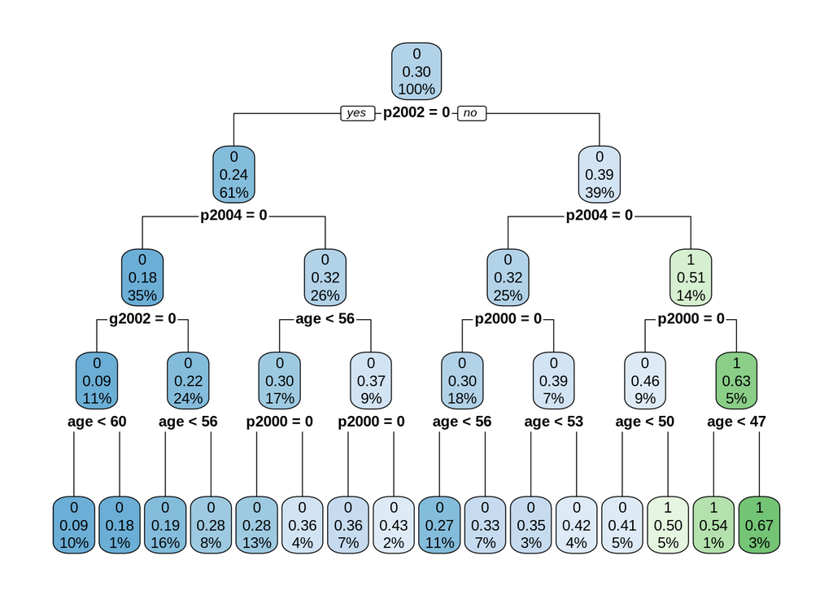

```r
#Refreshing the dataset since the previous ones were added with prediction columns
train <- gotv[-ind,]
test <- gotv[ind,]

model_tree_plot <- rpart(voted ~ ., data = train, method = "class", control = list(maxdepth = 4), cp = -1)
rpart.plot(model_tree_plot)
```

The not-so-nice original tree (created from rtree) with depth of 6 is given below

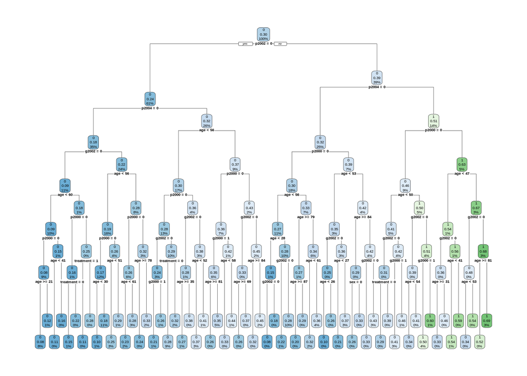

```r
rpart.plot(model_tree)
```

## Part d - Pruning the tree

```r
pruned_tree <- prune(model_tree, cp = 0.001)
test$pruned_pred <- predict(pruned_tree, newdata = test, type = "class")
pruned_test_error <- check_err(test$pruned_pred, test$voted)
```

Pruning the tree resulted in an increase in the classification error from 0.2900288 in the initial tree to 0.2905299 in the pruned tree.

We create a deeper tree, and then prune it to check if pruning can help further

```r
#Refreshing the dataset since the previous ones were added with prediction columns
train <- gotv[-ind,]
test <- gotv[ind,]

deeper_tree <- rpart(voted ~ ., data = train, method = "class", control = list(maxdepth = 32), cp = -1)
pruned_deeper_tree <- prune(deeper_tree, cp = 0.001)

test$deeper_pred <- predict(deeper_tree, newdata = test, type = "class")
test$pruned_pred <- predict(pruned_deeper_tree, newdata = test, type = "class")
deeper_test_error <- check_err(test$deeper_pred, test$voted)
pruned_test_error <- check_err(test$pruned_pred, test$voted)
```

Pruning a deeper tree resulted a decrease of classification error from 0.2926872 in the initial tree to 0.2894622 in the pruned tree.

## Part f - Creating a Random Forest

```r
create_RF <- function(df, pred_var, n_pred, percent_obs, num_trees, complex_param, max_depth) {
  #n_pred: number of variables to be used for each weak learner
  #percent_obs: percetange of the training set used for each tree
  #num_trees: number of weak learners to create the forest
  #complex_param: compexity parameter for the rpart
  #max_depth: depth of the trees created
  rforest <- list()

  for(i in 1:num_trees) {

    # Sampling predictors for creating a tree
    sampled_preds <- sample(pred_var, n_pred, replace = FALSE)

    # Sampling observations for training tree
    in_bag <- apply(df, MARGIN = 1, FUN = function(v) ifelse(runif(n = 1, min = 0, max = 1) <= percent_obs, 1, 0))
    temp_df <- cbind(df, in_bag)
    in_bag <- which(temp_df$in_bag == 1) # df rows which will be used to train the model

    # Building the tree
    t_control <- rpart.control(cp = complex_param, maxdepth = max_depth)
    tree <- rpart(formula = temp_df[in_bag,"voted"] ~ ., data = temp_df[in_bag,sampled_preds], method = "class", control = t_control)

    # add the tree to the forest
    rforest[[i]] <- tree
  }

  return(rforest)
}
```

```r
#Refreshing the dataset since the previous ones were added with prediction columns
train <- gotv[-ind,]
test <- gotv[ind,]
coln <- colnames(train)[1:8]

n_weak_learners <- 25 #number of trees
rf <- create_RF(train, coln, 5, 0.8, n_weak_learners, -1, 6)
```

```r
threshold <- n_weak_learners/2
#Defining a function to determine majority vote
majorityThres <- function(x) {
  if (x > threshold){
    return(1)
  }
  if (x < threshold){
    return(0)
  }
  if (x == threshold){
    return(rbinom(1,1,0.5)) #flipping a coin in case of a tie
  }
}
```

```r
#Predicting outcome for each tree
pred_columns <- c()
pred_df <- data.frame()
for (i in 1:n_weak_learners){
  new_col <- paste("pred",i, sep="_")
  test[[new_col]] <- predict(rf[[i]], newdata = test, type = "class")
  pred_columns[i] <- new_col
}

#Converting factor-level predictions into numeric type
indx <- sapply(test, is.factor)
test[indx] <- lapply(test[indx], function(x) as.numeric(as.character(x)))
test$sum <- rowSums(test[pred_columns])

#Taking a majority vote across different tree predictions
new_val <- lapply(test$sum, majorityThres)
test$RFPred <- new_val
rforest_test_err <- check_err(test$RFPred, test$voted)
print(rforest_test_err)
```

```
## [1] 0.291663
```

The classification error based on the Random Forest (with 25 weak learners) is 0.291663 compared to the single tree with a test error of 0.2900288